# Project - App Rating Prediction

```python
# Importing Libraries

import numpy as np
import pandas as pd
import matplotlib.pyplot as plt
import seaborn as sns
```

## Step 1

### Load the data file using pandas.

```python
# Load the data into a pandas DataFrame
google_data=pd.read_csv(r"C:\Users\Owner\Desktop\Simplilearn\Programming Basics and Data Analytics with Python\googleplaystore Project\googleplaystore.csv")

# Display the first few rows of the DataFrame to verify the data has been loaded
google_data.head()
```

|  | App | Category | Rating | Reviews | Size | Installs | Type | Price | Content Rating | Genres | Last Updated | Current Ver | Android Ver |
| --- | --- | --- | --- | --- | --- | --- | --- | --- | --- | --- | --- | --- | --- |
| 0 | Photo Editor & Candy Camera & Grid & ScrapBook | ART_AND_DESIGN | 4.1 | 159 | 19M | 10,000+ | Free | 0 | Everyone | Art & Design | January 7, 2018 | 1.0.0 | 4.0.3 and up |
| 1 | Coloring book moana | ART_AND_DESIGN | 3.9 | 967 | 14M | 500,000+ | Free | 0 | Everyone | Art & Design;Pretend Play | January 15, 2018 | 2.0.0 | 4.0.3 and up |
| 2 | U Launcher Lite – FREE Live Cool Themes, Hide ... | ART_AND_DESIGN | 4.7 | 87510 | 8.7M | 5,000,000+ | Free | 0 | Everyone | Art & Design | August 1, 2018 | 1.2.4 | 4.0.3 and up |
| 3 | Sketch - Draw & Paint | ART_AND_DESIGN | 4.5 | 215644 | 25M | 50,000,000+ | Free | 0 | Teen | Art & Design | June 8, 2018 | Varies with device | 4.2 and up |
| 4 | Pixel Draw - Number Art Coloring Book | ART_AND_DESIGN | 4.3 | 967 | 2.8M | 100,000+ | Free | 0 | Everyone | Art & Design;Creativity | June 20, 2018 | 1.1 | 4.4 and up |

## Step 2

### Check for null values in the data. Get the number of null values for each column.

```python
# Check for null values in the data
google_data.isna().sum()
```

```
App                  0
Category             0
Rating            1474
Reviews              0
Size                 0
Installs             0
Type                 1
Price                0
Content Rating       1
Genres               0
Last Updated         0
Current Ver          8
Android Ver          3
dtype: int64
```

```python
## Step 3
### Drop records with nulls in any of the columns.
```

```python
print('Before Removing Null Values : ',google_data.shape)

# Drop records with null values in any column
df=google_data.dropna(inplace = True)

# Updating so non null values can be updated into pre-existing dataset.
google_data.update(df)

print('After Removing Null Values : ',google_data.shape)

google_data.isna().sum()
```

```
Before Removing Null Values :  (10841, 13)
After Removing Null Values :  (9360, 13)
```

```
App               0
Category          0
Rating            0
Reviews           0
Size              0
Installs          0
Type              0
Price             0
Content Rating    0
Genres            0
Last Updated      0
Current Ver       0
Android Ver       0
dtype: int64
```

## Step 4

### Variables seem to have incorrect type and inconsistent formatting. You need to fix them:

### 4.1 Size column has sizes in Kb as well as Mb. To analyze, you’ll need to convert these to numeric.

### a) Extract the numeric value from the column

### b) Multiply the value by 1,000, if size is mentioned in Mb

```python
# Handling the size column :
def modify_size(obj):
    if 'M' in obj:
        x=obj[:-1] # Removing the 'M' Character from the end
        x=float(x)*1000 # Convert to float and multiply by 1000
        return x
    elif 'k'in obj:
        x=obj[:-1] # Removing the 'k' Character from the end
        x=float(x) # Convert to float
        return(x)
    else:
        return None

# Apply the modify_size function to each element in the "Size" column
google_data['Size']=google_data['Size'].map(modify_size)
```

```python
google_data.head(5)
```

|  | App | Category | Rating | Reviews | Size | Installs | Type | Price | Content Rating | Genres | Last Updated | Current Ver | Android Ver |
| --- | --- | --- | --- | --- | --- | --- | --- | --- | --- | --- | --- | --- | --- |
| 0 | Photo Editor & Candy Camera & Grid & ScrapBook | ART_AND_DESIGN | 4.1 | 159 | 19000.0 | 10,000+ | Free | 0 | Everyone | Art & Design | January 7, 2018 | 1.0.0 | 4.0.3 and up |
| 1 | Coloring book moana | ART_AND_DESIGN | 3.9 | 967 | 14000.0 | 500,000+ | Free | 0 | Everyone | Art & Design;Pretend Play | January 15, 2018 | 2.0.0 | 4.0.3 and up |
| 2 | U Launcher Lite – FREE Live Cool Themes, Hide ... | ART_AND_DESIGN | 4.7 | 87510 | 8700.0 | 5,000,000+ | Free | 0 | Everyone | Art & Design | August 1, 2018 | 1.2.4 | 4.0.3 and up |
| 3 | Sketch - Draw & Paint | ART_AND_DESIGN | 4.5 | 215644 | 25000.0 | 50,000,000+ | Free | 0 | Teen | Art & Design | June 8, 2018 | Varies with device | 4.2 and up |
| 4 | Pixel Draw - Number Art Coloring Book | ART_AND_DESIGN | 4.3 | 967 | 2800.0 | 100,000+ | Free | 0 | Everyone | Art & Design;Creativity | June 20, 2018 | 1.1 | 4.4 and up |

```python
google_data.info()
```

```
<class 'pandas.core.frame.DataFrame'>
Index: 9360 entries, 0 to 10840
Data columns (total 13 columns):
 #   Column          Non-Null Count  Dtype
---  ------          --------------  -----
 0   App             9360 non-null   object
 1   Category        9360 non-null   object
 2   Rating          9360 non-null   float64
 3   Reviews         9360 non-null   object
 4   Size            7723 non-null   float64
 5   Installs        9360 non-null   object
 6   Type            9360 non-null   object
 7   Price           9360 non-null   object
 8   Content Rating  9360 non-null   object
 9   Genres          9360 non-null   object
 10  Last Updated    9360 non-null   object
 11  Current Ver     9360 non-null   object
 12  Android Ver     9360 non-null   object
dtypes: float64(2), object(11)
memory usage: 1023.8+ KB
```

### 4.2 Reviews is a numeric field that is loaded as a string field. Convert it to numeric (int/float).

```python
# Convert the "Reviews" column to integer
google_data['Reviews']=google_data['Reviews'].astype(int)
```

```python
google_data.info()
```

```
<class 'pandas.core.frame.DataFrame'>
Index: 9360 entries, 0 to 10840
Data columns (total 13 columns):
 #   Column          Non-Null Count  Dtype
---  ------          --------------  -----
 0   App             9360 non-null   object
 1   Category        9360 non-null   object
 2   Rating          9360 non-null   float64
 3   Reviews         9360 non-null   int32
 4   Size            7723 non-null   float64
 5   Installs        9360 non-null   object
 6   Type            9360 non-null   object
 7   Price           9360 non-null   object
 8   Content Rating  9360 non-null   object
 9   Genres          9360 non-null   object
 10  Last Updated    9360 non-null   object
 11  Current Ver     9360 non-null   object
 12  Android Ver     9360 non-null   object
dtypes: float64(2), int32(1), object(10)
memory usage: 987.2+ KB
```

## 4.3 Installs field is currently stored as string and has values like 1,000,000+.

### a) Treat 1,000,000+ as 1,000,000

### b) Remove ‘+’, ‘,’ from the field, convert it to integer

```python
# a) Treat '1,000,000+' as 1,000,000
google_data['Installs']=google_data['Installs'].str.replace('+','')

# a) Treat '1,000,000+' as 1000000
google_data['Installs']=google_data['Installs'].str.replace(',','')

# b) Convert the "Installs" field to integer
google_data['Installs']=google_data['Installs'].astype(int)
```

```python
google_data.info()
```

```
<class 'pandas.core.frame.DataFrame'>
Index: 9360 entries, 0 to 10840
Data columns (total 13 columns):
 #   Column          Non-Null Count  Dtype
---  ------          --------------  -----
 0   App             9360 non-null   object
 1   Category        9360 non-null   object
 2   Rating          9360 non-null   float64
 3   Reviews         9360 non-null   int32
 4   Size            7723 non-null   float64
 5   Installs        9360 non-null   int32
 6   Type            9360 non-null   object
 7   Price           9360 non-null   object
 8   Content Rating  9360 non-null   object
 9   Genres          9360 non-null   object
 10  Last Updated    9360 non-null   object
 11  Current Ver     9360 non-null   object
 12  Android Ver     9360 non-null   object
dtypes: float64(2), int32(2), object(9)
memory usage: 950.6+ KB
```

```python
google_data.head(2)
```

|  | App | Category | Rating | Reviews | Size | Installs | Type | Price | Content Rating | Genres | Last Updated | Current Ver | Android Ver |
| --- | --- | --- | --- | --- | --- | --- | --- | --- | --- | --- | --- | --- | --- |
| 0 | Photo Editor & Candy Camera & Grid & ScrapBook | ART_AND_DESIGN | 4.1 | 159 | 19000.0 | 10000 | Free | 0 | Everyone | Art & Design | January 7, 2018 | 1.0.0 | 4.0.3 and up |
| 1 | Coloring book moana | ART_AND_DESIGN | 3.9 | 967 | 14000.0 | 500000 | Free | 0 | Everyone | Art & Design;Pretend Play | January 15, 2018 | 2.0.0 | 4.0.3 and up |

## 4.4 Price field is a string and has dollar symbol. Remove dollar sign, and convert it to float.

```python
# Remove the dollar sign from the "Price" column
google_data['Price']=google_data['Price'].str.replace('$','')

# Convert 'Price' column to float
google_data['Price']=google_data['Price'].astype(float)
```

```python
google_data.info()
```

```
<class 'pandas.core.frame.DataFrame'>
Index: 9360 entries, 0 to 10840
Data columns (total 13 columns):
 #   Column          Non-Null Count  Dtype
---  ------          --------------  -----
 0   App             9360 non-null   object
 1   Category        9360 non-null   object
 2   Rating          9360 non-null   float64
 3   Reviews         9360 non-null   int32
 4   Size            7723 non-null   float64
 5   Installs        9360 non-null   int32
 6   Type            9360 non-null   object
 7   Price           9360 non-null   float64
 8   Content Rating  9360 non-null   object
 9   Genres          9360 non-null   object
 10  Last Updated    9360 non-null   object
 11  Current Ver     9360 non-null   object
 12  Android Ver     9360 non-null   object
dtypes: float64(3), int32(2), object(8)
memory usage: 950.6+ KB
```

```python
google_data.head(2)
```

|  | App | Category | Rating | Reviews | Size | Installs | Type | Price | Content Rating | Genres | Last Updated | Current Ver | Android Ver |
| --- | --- | --- | --- | --- | --- | --- | --- | --- | --- | --- | --- | --- | --- |
| 0 | Photo Editor & Candy Camera & Grid & ScrapBook | ART_AND_DESIGN | 4.1 | 159 | 19000.0 | 10000 | Free | 0.0 | Everyone | Art & Design | January 7, 2018 | 1.0.0 | 4.0.3 and up |
| 1 | Coloring book moana | ART_AND_DESIGN | 3.9 | 967 | 14000.0 | 500000 | Free | 0.0 | Everyone | Art & Design;Pretend Play | January 15, 2018 | 2.0.0 | 4.0.3 and up |

## Step 5 Sanity checks:

### 5.1 Average rating should be between 1 and 5 as only these values are allowed on the play store. Drop the rows that have a value outside this range.

```python
google_data['Rating'].min(),google_data['Rating'].max()
```

```
(1.0, 5.0)
```

### 5.2 Reviews should not be more than installs as only those who installed can review the app. If there are any such records, drop them.

```python
# Rows before filtering
google_data.shape
```

```
(9360, 13)
```

```python
# Identifying the number of rows where reviews greater than installs
google_data[google_data['Reviews']>google_data['Installs']].index
```

```
Index([2454, 4663, 5917, 6700, 7402, 8591, 10697], dtype='int64')
```

```python
# Filter rows where the number of "Reviews" is less than or equal to the number of "Installs"
google_data=google_data.loc[google_data['Reviews']<=google_data['Installs'],]
```

```python
# Rows after filtering
google_data.shape
```

```
(9353, 13)
```

### 5.3 For free apps (type = “Free”), the price should not be >0. Drop any such rows.

```python
# Count the number of rows where the app type is "Free" and the price is greater than 0
len(google_data[(google_data.Type=='Free')&(google_data.Price>0)])
```

```
0
```

## Step 6 Performing univariate analysis:

### 6.1 Boxplot for Price

### Are there any outliers? Think about the price of usual apps on Play Store.

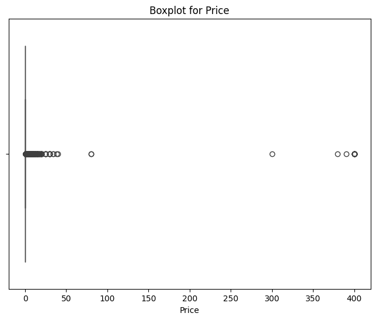

```python
# Create a boxplot for the "Price" column
plt.figure(figsize=(8, 6))
sns.boxplot(x=google_data['Price'])

# # Set the title and labels
plt.title('Boxplot for Price')
plt.xlabel('Price')

# Display the plot
plt.show()
```

### Output for Box Plot of Price

### The visual shows 95% of apps are under 50 dollars indicating that only a small percentage of apps have prices higher than $50, making them potential outliers.

### 6.2 Boxplot for Reviews

### Are there any apps with very high number of reviews? Do the values seem right?

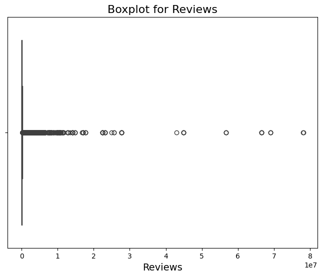

```python
# Create a boxplot for the "Price" column
plt.figure(figsize=(8, 6))
sns.boxplot(x=google_data['Reviews'])

# # Set the title and labels
plt.title('Boxplot for Reviews',fontsize=16)
plt.xlabel('Reviews',fontsize=14)

# Display the plot
plt.show()
```

### Output for BoxPlot of Reviews

### The visual shows majority of reviews are under 2 million indicating reviews for apps greater than 2 million can be considered as outliers.

### 6.3 Histogram for Rating

### How are the ratings distributed? Is it more toward higher ratings?

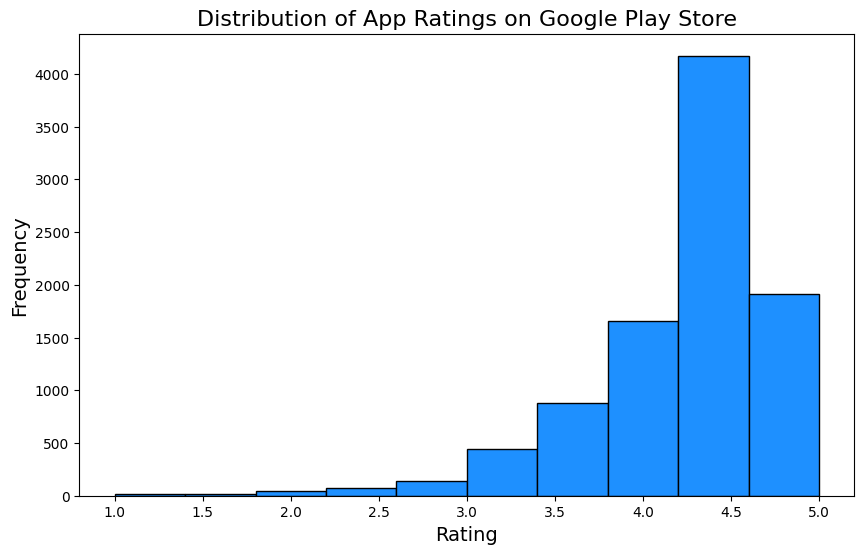

```python
# Create a histogram for the "Rating" column
plt.figure(figsize=(10, 6))
google_data['Rating'].plot.hist(color='dodgerblue', edgecolor='black')
# Set the title and labels
plt.title('Distribution of App Ratings on Google Play Store',fontsize=16)
plt.xlabel('Rating',fontsize=14)
plt.ylabel('Frequency',fontsize=14)

# Display the plot
plt.show()
```

### Output for Histogram for Rating

### A left-skewed distribution in the context of app ratings means that there's a positive trend where most apps receive higher ratings, with a smaller number of apps receiving lower ratings. This is often a desirable pattern, as higher ratings are indicative of user satisfaction.

### 6.4 Histogram for Size

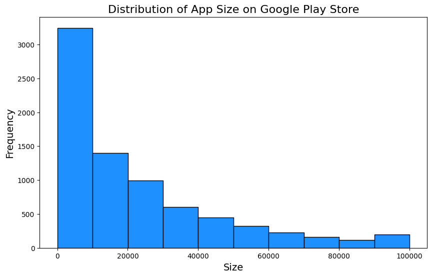

```python
# Create a histogram for the "Size" column
plt.figure(figsize=(10, 6))
google_data['Size'].plot.hist(color='dodgerblue', edgecolor='black')
# Set the title and labels
plt.title('Distribution of App Size on Google Play Store',fontsize=16)
plt.xlabel('Size',fontsize=14)
plt.ylabel('Frequency',fontsize=14)

# Display the plot
plt.show()
```

### Output for Histogram on Size

### A right-skewed distribution in the context of app sizes means that there's a positive trend where most apps have smaller file sizes, with a smaller number of apps having larger sizes.

## 7. Outlier treatment:

### 7.1 Price: From the box plot, it seems like there are some apps with very high price. A price of $200 for an application on the Play Store is very high and suspicious!

### Check out the records with very high price

### Is 200 indeed a high price?

### Drop these as most seem to be junk apps

```python
# Checking for apps with Price > 200
len(google_data[google_data.Price>200])
```

```
15
```

```python
# Before Filtering
google_data.shape
```

```
(9353, 13)
```

```python
# Dropping 15 rows where Price > $200
google_data.drop(google_data[google_data['Price']>200].index,inplace=True)
```

```python
# After Filtering
google_data.shape
```

```
(9338, 13)
```

### 7.2 Reviews: Very few apps have very high number of reviews. These are all star apps that don’t help with the analysis and, in fact, will skew it. Drop records having more than 2 million reviews.

```python
# Checking for apps having greater than  2 million reviews
len(google_data[google_data.Reviews>2000000])
```

```
453
```

```python
# Before Filtering
google_data.shape
```

```
(9338, 13)
```

```python
# Dropping rows greater than 2 million reviws
google_data.drop(google_data[google_data['Reviews']>2000000].index,inplace=True)
```

```python
# After Filtering
google_data.shape
```

```
(8885, 13)
```

### 7.3 Installs: There seems to be some outliers in this field too. Apps having very high number of installs should be dropped from the analysis.

### a) Find out the different percentiles – 10, 25, 50, 70, 90, 95, 99

### b) Decide a threshold as cutoff for outlier and drop records having values more than that

```python
# Calculate quantiles for the "Installs" column to understand the distribution
# Lets have a threshold cutoff at 100000000
google_data['Installs'].quantile([.10,.25,.50,.70,.90,.95,.99])
```

```
0.10         1000.0
0.25        10000.0
0.50       500000.0
0.70      1000000.0
0.90     10000000.0
0.95     10000000.0
0.99    100000000.0
Name: Installs, dtype: float64
```

```python
# Before Filtering
google_data.shape
```

```
(8885, 13)
```

```python
# Number of apps having installs more than 100000000
len(google_data[google_data.Installs>100000000])
```

```
20
```

```python
# Dropping these 20 apps
google_data.drop(google_data[google_data['Installs']>100000000].index,inplace=True)
```

```python
# After Filtering
google_data.shape
```

```
(8865, 13)
```

### Step 8. Bivariate analysis: Let’s look at how the available predictors relate to the variable of interest, i.e., our target variable rating. Make scatter plots (for numeric features) and box plots (for character features) to assess the relations between rating and the other features.

### 8.1 Make scatter plot/joinplot for Rating vs. Price. What pattern do you observe? Does rating increase with price?

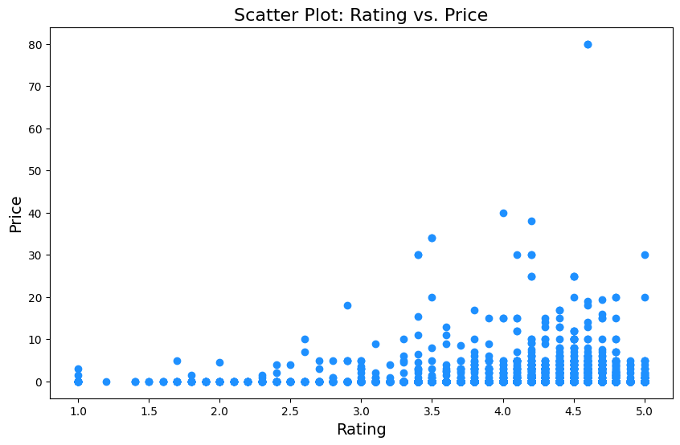

```python
# Scatterplot between rating and price
plt.figure(figsize=(10, 6))
plt.scatter(x='Rating', y='Price', data=google_data, color='dodgerblue')

# Setting the Title and Label
plt.title('Scatter Plot: Rating vs. Price', fontsize=16)
plt.xlabel('Rating', fontsize=14)
plt.ylabel('Price', fontsize=14)

# Display the plot
plt.show()
```

### 8.2 Make scatter plot/joinplot for Rating vs. Size

### Are heavier apps rated better?

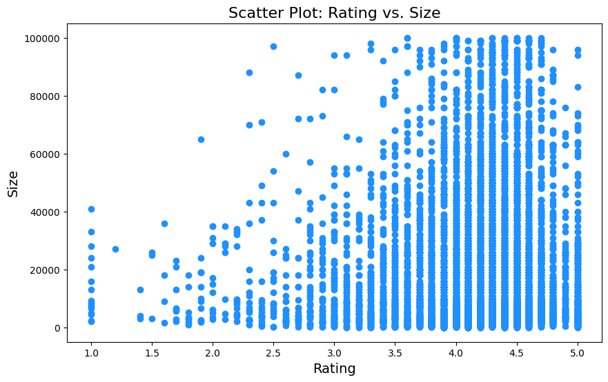

```python
# Scatterplot between rating and size
plt.figure(figsize=(10, 6))
plt.scatter(x='Rating', y='Size', data=google_data, color='dodgerblue')

# Setting the Title and Label
plt.title('Scatter Plot: Rating vs. Size', fontsize=16)
plt.xlabel('Rating', fontsize=14)
plt.ylabel('Size', fontsize=14)

# Display the plot
plt.show()
```

## Output for this visual

### 8.3 Make scatter plot/joinplot for Rating vs. Reviews

### Does more review mean a better rating always?

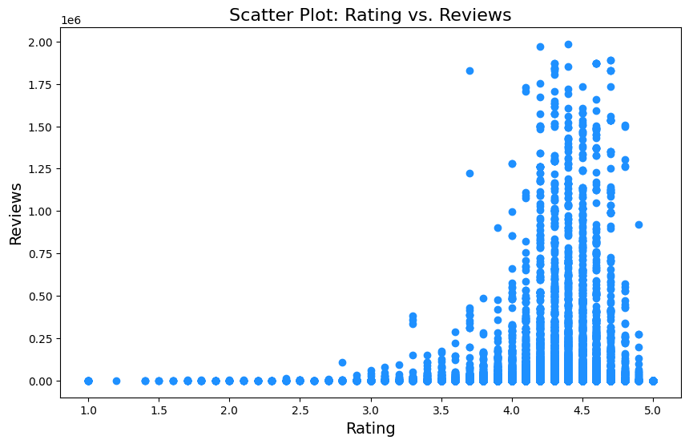

```python
# Scatterplot between rating and reviews
plt.figure(figsize=(10, 6))
plt.scatter(x='Rating', y='Reviews', data=google_data, color='dodgerblue')

# Setting the Title and Label
plt.title('Scatter Plot: Rating vs. Reviews', fontsize=16)
plt.xlabel('Rating', fontsize=14)
plt.ylabel('Reviews', fontsize=14)

# Display the plot
plt.show()
```

### Output for this visual

### Higher numbers of reviews often indicate greater user engagement with the app. Users who are satisfied or happy with their experience are more likely to take the time to leave a review, contributing to a larger number of reviews.

### 8.4 Make boxplot for Rating vs. Content Rating

### Is there any difference in the ratings? Are some types liked better?

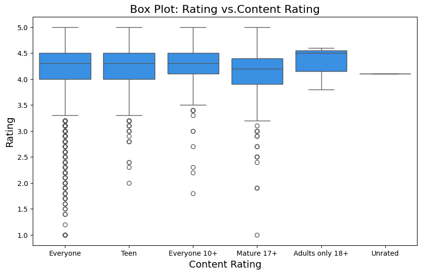

```python
# Boxplot between rating and reviews
plt.figure(figsize=(10, 6))
sns.boxplot(x='Content Rating',y='Rating',data=google_data,color='dodgerblue')

# Setting the Title and Label
plt.title('Box Plot: Rating vs.Content Rating', fontsize=16)
plt.xlabel('Content Rating', fontsize=14)
plt.ylabel('Rating', fontsize=14)

# Display the plot
plt.show()
```

### 8.5 Make boxplot for Ratings vs. Category

### Which genre has the best ratings?

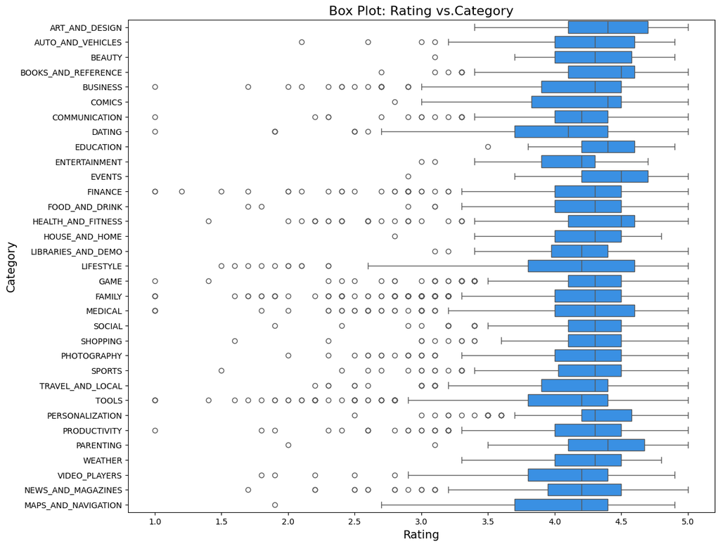

```python
# Boxplot between rating and reviews
plt.figure(figsize=(13,11))
sns.boxplot(x='Rating',y='Category',data=google_data,color='dodgerblue')

# Setting the Title and Label
plt.title('Box Plot: Rating vs.Category', fontsize=16)
plt.xlabel('Rating', fontsize=14)
plt.ylabel('Category', fontsize=14)

# Display the plot
plt.show()
```